# EasyVisa Project

### Bivariate Analysis

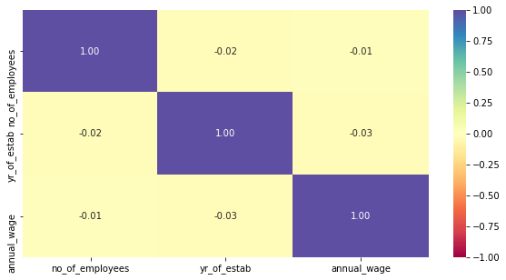

```python
cols_list = data.select_dtypes(include=np.number).columns.tolist()

plt.figure(figsize=(10, 5))
sns.heatmap(
    data[cols_list].corr(), annot=True, vmin=-1, vmax=1, fmt=".2f", cmap="Spectral"
) ## Complete the code to find the correlation between the variables
plt.show()
```

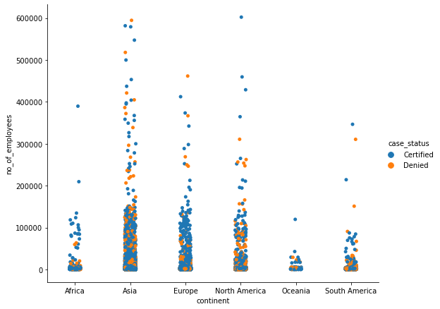

```python
sns.catplot(x="continent", y='no_of_employees', data=data, hue='case_status', size=6, aspect=1.25, estimator=np.mean);
```

- It seems Asia continent has most number of employees.

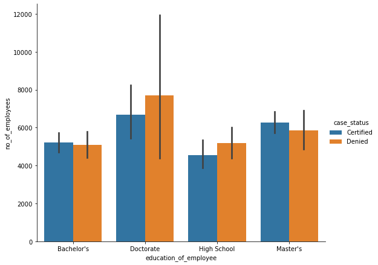

```python
sns.catplot(x="education_of_employee", y='no_of_employees',  data=data, hue='case_status', kind= 'bar', size=6, aspect=1.25, estimator=np.mean);
```

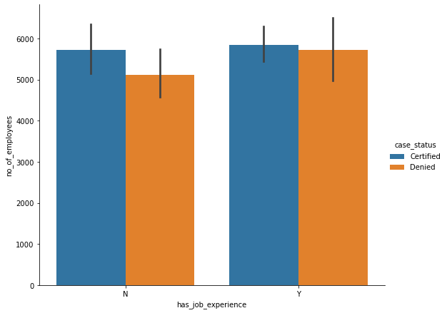

```python
sns.catplot(x="has_job_experience", y='no_of_employees',  data=data, hue='case_status', kind= 'bar', size=6, aspect=1.25, estimator=np.mean);
```

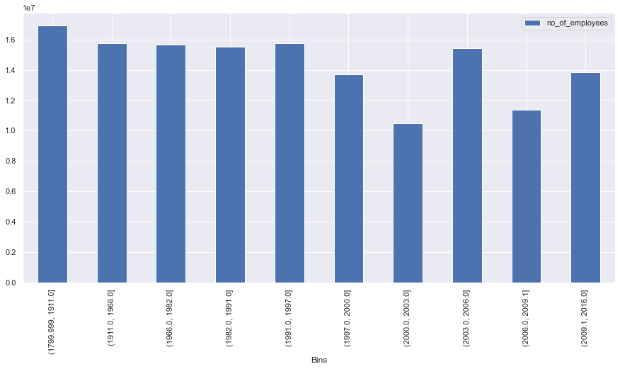

```python
data['Bins'] =  pd.qcut(data['yr_of_estab'], 10)
sns.set(rc={'figure.figsize':(15,7)})
pd.pivot_table(data=data, index=['Bins'], values= 'no_of_employees', aggfunc=np.sum).plot(kind='bar');
```

- Employees are more or less evenly distributed among the old and newer companies. However, companies established between 2000 and 2003 have least amount of employees. Companies established before 1911 have employed highest amount of employees.

**Creating function to further analyze the data

```python
### function to plot distributions wrt target


def distribution_plot_wrt_target(data, predictor, target):

    fig, axs = plt.subplots(2, 2, figsize=(12, 10))

    target_uniq = data[target].unique()

    axs[0, 0].set_title("Distribution of target for target=" + str(target_uniq[0]))
    sns.histplot(
        data=data[data[target] == target_uniq[0]],
        x=predictor,
        kde=True,
        ax=axs[0, 0],
        color="teal",
        stat="density",
    )

    axs[0, 1].set_title("Distribution of target for target=" + str(target_uniq[1]))
    sns.histplot(
        data=data[data[target] == target_uniq[1]],
        x=predictor,
        kde=True,
        ax=axs[0, 1],
        color="orange",
        stat="density",
    )

    axs[1, 0].set_title("Boxplot w.r.t target")
    sns.boxplot(data=data, x=target, y=predictor, ax=axs[1, 0], palette="gist_rainbow")

    axs[1, 1].set_title("Boxplot (without outliers) w.r.t target")
    sns.boxplot(
        data=data,
        x=target,
        y=predictor,
        ax=axs[1, 1],
        showfliers=False,
        palette="gist_rainbow",
    )

    plt.tight_layout()
    plt.show()
```

```python
def stacked_barplot(data, predictor, target):
    """
    Print the category counts and plot a stacked bar chart

    data: dataframe
    predictor: independent variable
    target: target variable
    """
    count = data[predictor].nunique()
    sorter = data[target].value_counts().index[-1]
    tab1 = pd.crosstab(data[predictor], data[target], margins=True).sort_values(
        by=sorter, ascending=False
    )
    print(tab1)
    print("-" * 120)
    tab = pd.crosstab(data[predictor], data[target], normalize="index").sort_values(
        by=sorter, ascending=False
    )
    tab.plot(kind="bar", stacked=True, figsize=(count + 5, 5))
    plt.legend(
        loc="lower left", frameon=False,
    )
    plt.legend(loc="upper left", bbox_to_anchor=(1, 1))
    plt.show()
```

**Let's find out if education has any impact on visa certification**

```
case_status            Certified  Denied    All
education_of_employee
All                        17018    8462  25480
Bachelor's                  6367    3867  10234
High School                 1164    2256   3420
Master's                    7575    2059   9634
Doctorate                   1912     280   2192
------------------------------------------------------------------------------------------------------------------------
```

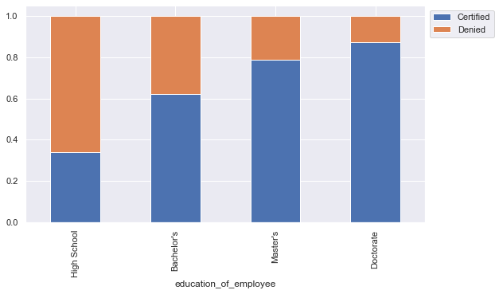

```python
stacked_barplot(data, "education_of_employee", "case_status")
```

- Employees with doctorate degrees are highly likely to get visa certified. And with high school, proportion of visas denied is high.

```
case_status         Certified  Denied    All
has_job_experience
All                     17018    8462  25480
N                        5994    4684  10678
Y                       11024    3778  14802
------------------------------------------------------------------------------------------------------------------------
```

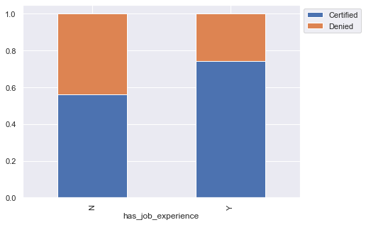

```python
stacked_barplot(data, "has_job_experience", "case_status")
```

- Employees with job experience have had better chances of getting visa certified than that of no experience.

```
case_status            Certified  Denied    All
requires_job_training
All                        17018    8462  25480
N                          15012    7513  22525
Y                           2006     949   2955
------------------------------------------------------------------------------------------------------------------------
```

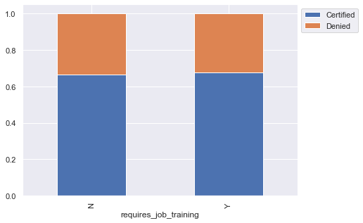

```python
stacked_barplot(data, "requires_job_training", "case_status")
```

- Job training requirement probably doesn't play much role in visa certification as shown by the plot.

```
case_status         Certified  Denied    All
full_time_position
All                     17018    8462  25480
Y                       15163    7610  22773
N                        1855     852   2707
------------------------------------------------------------------------------------------------------------------------
```

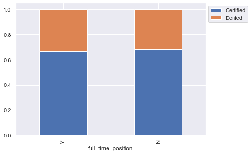

```python
stacked_barplot(data, "full_time_position", "case_status")
```

- Proportionally, job type probably doesn't play much role in visa certification either as shown by the plot.

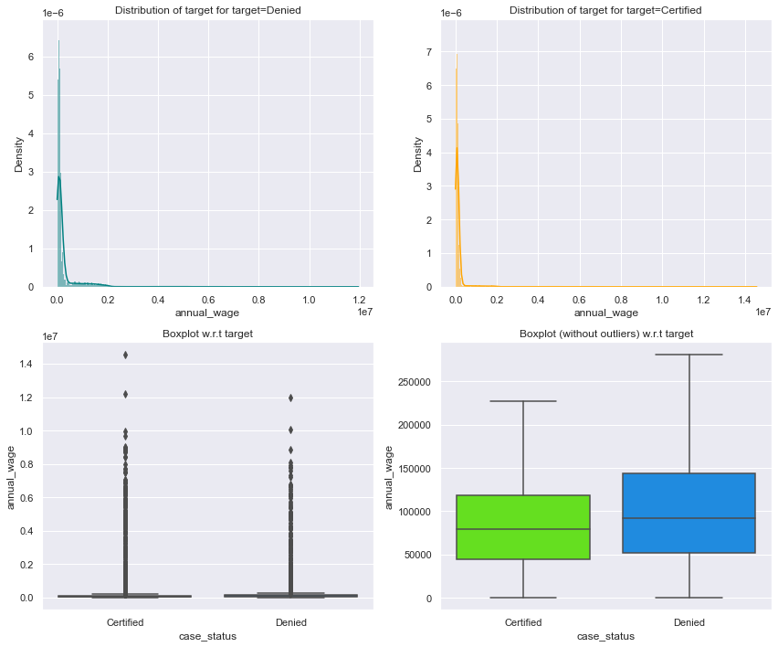

```python
distribution_plot_wrt_target(data, 'annual_wage', 'case_status')
```

```python
data.columns
```

```
Index(['continent', 'education_of_employee', 'has_job_experience',
       'requires_job_training', 'no_of_employees', 'yr_of_estab',
       'region_of_employment', 'full_time_position', 'case_status',
       'annual_wage', 'Bins'],
      dtype='object')
```

```python
data.drop(columns=['Bins'], inplace= True) #Dropping the Bins column
```

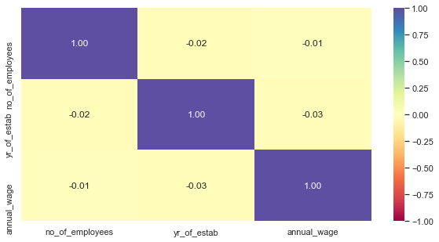

```python
cols_list = data.select_dtypes(include=np.number).columns.tolist()

plt.figure(figsize=(10, 5))
sns.heatmap(
    data[cols_list].corr(), annot=True, vmin=-1, vmax=1, fmt=".2f", cmap="Spectral"
) ## Complete the code to find the correlation between the variables
plt.show()
```

```python
data.isna().sum()
```

```
continent                0
education_of_employee    0
has_job_experience       0
requires_job_training    0
no_of_employees          0
yr_of_estab              0
region_of_employment     0
full_time_position       0
case_status              0
annual_wage              0
dtype: int64
```

- No missing Values
- Since we are going to run different models of higher predicting capability, we will let model to decide how it uses the datasets. Hence we **shall not treat outliers**.

**Preparing the dataset for modeling**

- Drop target variables from the data
- Create dummy variables
- Split data in train and test sets

```python
## create dummies
dummy_data= pd.get_dummies(data, columns=['continent','education_of_employee','has_job_experience','requires_job_training','region_of_employment', 'full_time_position'],
drop_first = True)
```

### Splitting data

```python
dummy_data["case_status"] = dummy_data["case_status"].apply(lambda x: 1 if x == "Certified" else 0)
```

```python
dummy_data.head()
```

|  | no_of_employees | yr_of_estab | case_status | annual_wage | continent_Asia | continent_Europe | continent_North America | continent_Oceania | continent_South America | education_of_employee_Doctorate | education_of_employee_High School | education_of_employee_Master's | has_job_experience_Y | requires_job_training_Y | region_of_employment_Midwest | region_of_employment_Northeast | region_of_employment_South | region_of_employment_West | full_time_position_Y |
| --- | --- | --- | --- | --- | --- | --- | --- | --- | --- | --- | --- | --- | --- | --- | --- | --- | --- | --- | --- |
| 0 | 14513 | 2007 | 0 | 1231782.032 | 1 | 0 | 0 | 0 | 0 | 0 | 1 | 0 | 0 | 0 | 0 | 0 | 0 | 1 | 1 |
| 1 | 2412 | 2002 | 1 | 83425.650 | 1 | 0 | 0 | 0 | 0 | 0 | 0 | 1 | 1 | 0 | 0 | 1 | 0 | 0 | 1 |
| 2 | 44444 | 2008 | 0 | 122996.860 | 1 | 0 | 0 | 0 | 0 | 0 | 0 | 0 | 0 | 1 | 0 | 0 | 0 | 1 | 1 |
| 3 | 98 | 1897 | 0 | 83434.030 | 1 | 0 | 0 | 0 | 0 | 0 | 0 | 0 | 0 | 0 | 0 | 0 | 0 | 1 | 1 |
| 4 | 1082 | 2005 | 1 | 149907.390 | 0 | 0 | 0 | 0 | 0 | 0 | 0 | 1 | 1 | 0 | 0 | 0 | 1 | 0 | 1 |

```python
X = dummy_data.drop("case_status", axis=1)
y = dummy_data["case_status"]
```

```python
# Splitting data in train and test sets in the ratio 70:30
X_train, X_test, y_train, y_test = train_test_split(X, y, test_size= 0.30, random_state=1,stratify=y)
```

```python
X_train.shape, X_test.shape
```

```
((17836, 18), (7644, 18))
```

```python
y_test.value_counts()
```

```
1    5105
0    2539
Name: case_status, dtype: int64
```

```python
X_train
```

|  | no_of_employees | yr_of_estab | annual_wage | continent_Asia | continent_Europe | continent_North America | continent_Oceania | continent_South America | education_of_employee_Doctorate | education_of_employee_High School | education_of_employee_Master's | has_job_experience_Y | requires_job_training_Y | region_of_employment_Midwest | region_of_employment_Northeast | region_of_employment_South | region_of_employment_West | full_time_position_Y |
| --- | --- | --- | --- | --- | --- | --- | --- | --- | --- | --- | --- | --- | --- | --- | --- | --- | --- | --- |
| 21 | 1706 | 2013 | 137694.98 | 0 | 0 | 1 | 0 | 0 | 0 | 0 | 1 | 1 | 0 | 1 | 0 | 0 | 0 | 0 |
| 7332 | 2321 | 2009 | 11641.40 | 0 | 1 | 0 | 0 | 0 | 1 | 0 | 0 | 0 | 0 | 0 | 0 | 0 | 1 | 1 |
| 20579 | 1923 | 2005 | 21688.56 | 0 | 0 | 1 | 0 | 0 | 0 | 0 | 0 | 0 | 0 | 0 | 1 | 0 | 0 | 1 |
| 22326 | 434 | 1998 | 58341.54 | 1 | 0 | 0 | 0 | 0 | 0 | 1 | 0 | 0 | 0 | 1 | 0 | 0 | 0 | 1 |
| 13237 | 5870 | 2011 | 140996.50 | 1 | 0 | 0 | 0 | 0 | 0 | 1 | 0 | 1 | 0 | 0 | 1 | 0 | 0 | 1 |
| ... | ... | ... | ... | ... | ... | ... | ... | ... | ... | ... | ... | ... | ... | ... | ... | ... | ... | ... |
| 3629 | 1325 | 1911 | 56118.94 | 1 | 0 | 0 | 0 | 0 | 0 | 1 | 0 | 1 | 0 | 1 | 0 | 0 | 0 | 1 |
| 17771 | 1758 | 1990 | 19196.84 | 0 | 1 | 0 | 0 | 0 | 1 | 0 | 0 | 0 | 0 | 1 | 0 | 0 | 0 | 1 |
| 17863 | 468 | 1955 | 51730.55 | 0 | 0 | 1 | 0 | 0 | 1 | 0 | 0 | 0 | 0 | 0 | 0 | 0 | 1 | 1 |
| 6602 | 3788 | 1984 | 50166.77 | 0 | 0 | 0 | 0 | 1 | 0 | 0 | 1 | 1 | 0 | 0 | 0 | 0 | 1 | 1 |
| 22922 | 4743 | 2007 | 117715.69 | 1 | 0 | 0 | 0 | 0 | 0 | 0 | 0 | 1 | 0 | 0 | 1 | 0 | 0 | 1 |

17836 rows × 18 columns

- There are 17,836 observations in the train set and 7,644 observations in the test set.

### Before building models

**Things to consider**

1. Model predicts that the visa application will get certified but in reality, the visa application should get denied.
2. Model predicts that the visa application will not get certified but in reality, the visa application should get certified.
- Both the cases are important as:
- If a visa is certified when it had to be denied a wrong employee will get the job position while US citizens will miss the opportunity to work on that position.
- If a visa is denied when it had to be certified the U.S. will lose a suitable human resource that can contribute to the economy.

### To reduce the losses

**First, let's create functions to calculate different metrics and confusion matrix so that we don't have to use the same code repeatedly for each model.**

- The `get_score` function will be used to check the model performance of models.
- The `confusion_matrix` function will be used to plot confusion matrix.

```python
def get_score(model, predictors, target):
    """
    Function to compute different metrics to check classification model performance

    model: classifier
    predictors: independent variables
    target: dependent variable
    """

    # predicting using the independent variables
    pred = model.predict(predictors)

    acc = accuracy_score(target, pred)  # to compute Accuracy
    recall = recall_score(target, pred)  # to compute Recall
    precision = precision_score(target, pred)  # to compute Precision
    f1 = f1_score(target, pred)  # to compute F1-score

    # creating a dataframe of metrics
    df_perf = pd.DataFrame(
        {"Accuracy": acc, "Recall": recall, "Precision": precision, "F1": f1,},
        index=[0],
    )

    return df_perf
```

```python
def confusion_matrix_sklearn(model, predictors, target):
    """
    To plot the confusion_matrix with percentages

    model: classifier
    predictors: independent variables
    target: dependent variable
    """
    y_pred = model.predict(predictors)
    cm = confusion_matrix(target, y_pred)
    labels = np.asarray(
        [
            ["{0:0.0f}".format(item) + "\n{0:.2%}".format(item / cm.flatten().sum())]
            for item in cm.flatten()
        ]
    ).reshape(2, 2)

    plt.figure(figsize=(6, 4))
    sns.heatmap(cm, annot=labels, fmt="")
    plt.ylabel("True label")
    plt.xlabel("Predicted label")
```

### Decision Tree Model

**Keeping the class weight balanced as both certified(1) and denied(0) are important for us to predict.**

```python
model = DecisionTreeClassifier(
    criterion="gini", class_weight='balanced', random_state=1
) ## to define decision tree classifier with random state = 1
```

```python
model.fit(X_train, y_train) ## to fit decision tree classifier on the train data
```

```
DecisionTreeClassifier(class_weight='balanced', random_state=1)
```

**Checking performance with confusion matrix on the Training set.**

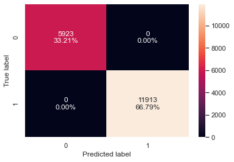

```python
confusion_matrix_sklearn(model, X_train, y_train)
```

```python
dtree_model_perf= get_score(model, X_train, y_train)
```

```python
print("Training performance \n", dtree_model_perf)
```

```
Training performance
    Accuracy  Recall  Precision   F1
0       1.0     1.0        1.0  1.0
```

**Checking performance on Test set.**

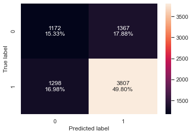

```python
confusion_matrix_sklearn(model, X_test , y_test)
```

```python
dtree_model_perf_train= get_score(model, X_train, y_train)
print("Testing performance \n", dtree_model_perf_train)
```

```
Testing performance
    Accuracy  Recall  Precision   F1
0       1.0     1.0        1.0  1.0
```

```python
dtree_model_perf_test= get_score(model, X_test, y_test)
```

```python
print("Testing performance \n", dtree_model_perf_test)
```

```
Testing performance
    Accuracy    Recall  Precision        F1
0  0.651361  0.745739   0.735794  0.740734
```

- **Both training and test datasets are showing discrepancy on F1 score between test and training set, which we will look at below and tune into.**
- **Lets look at the feature importance of the predictors.**

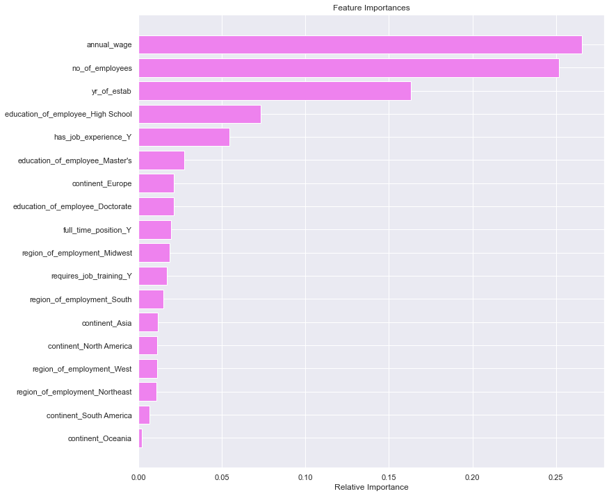

```python
feature_names = X_train.columns.to_list()
importances = model.feature_importances_
indices = np.argsort(importances)

plt.figure(figsize=(12, 12))
plt.title("Feature Importances")
plt.barh(range(len(indices)), importances[indices], color="violet", align="center")
plt.yticks(range(len(indices)), [feature_names[i] for i in indices])
plt.xlabel("Relative Importance")
plt.show()
```

**We will Use GridSearch for Hyperparameter tuning of our tree model that is exhaustive search that is performed on a the specific parameter values of a model.**

```python
# Choose the type of classifier.
estimator = DecisionTreeClassifier(random_state=1, class_weight='balanced')

# Grid of parameters to choose from
parameters = {
    "max_depth": [5, 10, 15, None],
    "criterion": ["entropy", "gini"],
    "splitter": ["best", "random"],
    "min_impurity_decrease": [0.00001, 0.0001, 0.01],
}

# Type of scoring used to compare parameter combinations
scorer = make_scorer(recall_score)

# Run the grid search
grid_obj = GridSearchCV(estimator, parameters, scoring=scorer, cv=5)
grid_obj = grid_obj.fit(X_train, y_train)

# Set the clf to the best combination of parameters
estimator = grid_obj.best_estimator_

# Fit the best algorithm to the data.
estimator.fit(X_train, y_train)
```

```
DecisionTreeClassifier(class_weight='balanced', max_depth=10,
                       min_impurity_decrease=0.0001, random_state=1,
                       splitter='random')
```

**Checking performance on confusion matrix for training data**

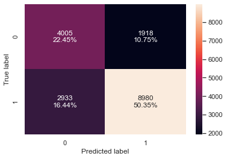

```python
confusion_matrix_sklearn(estimator, X_train, y_train)
```

```python
dtree_estmodel_perf_train = get_score(estimator, X_train, y_train)
print("Training performance \n", dtree_estmodel_perf_train)
```

```
Training performance
    Accuracy    Recall  Precision        F1
0  0.728022  0.753798   0.824004  0.787339
```

**Checking performance on confusion mattrix for test data**

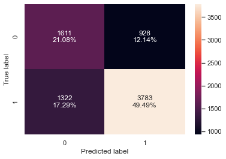

```python
confusion_matrix_sklearn(estimator, X_test , y_test)
```

```python
dtree_estmodel_perf_test= get_score(estimator, X_test, y_test)
print("Testing performance \n", dtree_estmodel_perf_test)
```

```
Testing performance
    Accuracy    Recall  Precision        F1
0  0.705651  0.741038   0.803014  0.770782
```

**Checking the feature importance after hyperparameter tuning**

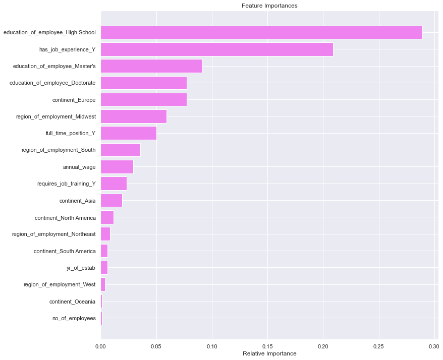

```python
importances = estimator.feature_importances_
indices = np.argsort(importances)

plt.figure(figsize=(12, 12))
plt.title("Feature Importances")
plt.barh(range(len(indices)), importances[indices], color="violet", align="center")
plt.yticks(range(len(indices)), [feature_names[i] for i in indices])
plt.xlabel("Relative Importance")
plt.show()
```

- After hyperparameter tuning, there was slight improvement in the overall score of the model and the most important factor changed from `annual wage` to `High school education` followed by `job experience`.
- Hyperparameter tuning is tricky and exhaustive in the sense that there is no direct way to calculate how a change in the hyperparameter value will reduce the loss of your model until you try those hyperparameters.

### Moving on to Building bagging and boosting models

### Bagging Classifier

```python
bagging_estimator=BaggingClassifier(random_state=1)
bagging_estimator.fit(X_train,y_train)
```

```
BaggingClassifier(random_state=1)
```

**Checking model performance on training data**

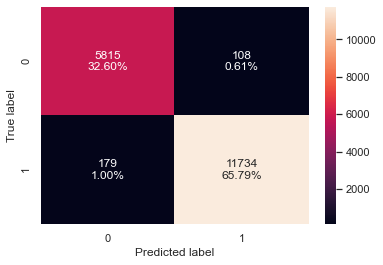

```python
confusion_matrix_sklearn(bagging_estimator, X_train, y_train)
```

```python
bagging_model_perf_train= get_score(bagging_estimator, X_train, y_train)
print("Training performance \n", bagging_model_perf_train)
```

```
Training performance
    Accuracy    Recall  Precision        F1
0  0.983909  0.984974    0.99088  0.987918
```

**Checking model performance on test dataset**

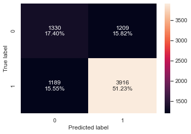

```python
confusion_matrix_sklearn(bagging_estimator, X_test, y_test)
```

```python
bagging_model_perf_test= get_score(bagging_estimator, X_test, y_test)
print("Training performance \n", bagging_model_perf_test)
```

```
Training performance
    Accuracy    Recall  Precision        F1
0   0.68629  0.767091   0.764098  0.765591
```

**Tuning our bagging classifier model as there is some discrepancy in the prediction of training and testing data**

```python
bagging_estimator_tuned = BaggingClassifier(random_state=1)

# Grid of parameters to choose from
## add from article
parameters = {'max_samples': [0.7,0.8,0.9,1],
              'max_features': [0.7,0.8,0.9,1],
              'n_estimators' : [10,20,30,40,50],
             }

# Type of scoring used to compare parameter combinations
acc_scorer = metrics.make_scorer(metrics.recall_score)

# Run the grid search
grid_obj = GridSearchCV(bagging_estimator_tuned, parameters, scoring=acc_scorer,cv=5)
grid_obj = grid_obj.fit(X_train, y_train)

# Set the clf to the best combination of parameters
bagging_estimator_tuned = grid_obj.best_estimator_

# Fit the best algorithm to the data.
bagging_estimator_tuned.fit(X_train, y_train)
```

```
BaggingClassifier(max_features=0.7, max_samples=1, random_state=1)
```

**Checking model performance after tuning (training data)**

```python
bagging_model_perf_train_tuned= get_score(bagging_estimator_tuned, X_train, y_train)
print("Training performance \n", bagging_model_perf_train_tuned)
```

```
Training performance
    Accuracy  Recall  Precision        F1
0  0.667919     1.0   0.667919  0.800901
```

```python
bagging_model_perf_test_tuned= get_score(bagging_estimator_tuned, X_test, y_test)
print("Training performance \n", bagging_model_perf_test_tuned)
```

```
Training performance
    Accuracy  Recall  Precision        F1
0  0.667844     1.0   0.667844  0.800847
```

### Random Forest Classifier

```python
#train the random forest classifier
rf_estimator=RandomForestClassifier(random_state=1)
rf_estimator.fit(X_train,y_train)
```

```
RandomForestClassifier(random_state=1)
```

```python
rf_estimator_perf_train= get_score(rf_estimator, X_train, y_train)
print("Training performance \n", rf_estimator_perf_train)
```

```
Training performance
    Accuracy    Recall  Precision        F1
0  0.999944  0.999916        1.0  0.999958
```

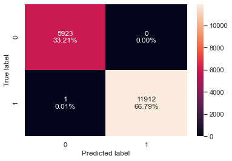

```python
confusion_matrix_sklearn(rf_estimator, X_train, y_train)
```

```python
rf_estimator_perf_test= get_score(rf_estimator, X_test, y_test)
print("Training performance \n", rf_estimator_perf_test)
```

```
Training performance
    Accuracy    Recall  Precision        F1
0  0.715986  0.831146   0.764229  0.796284
```

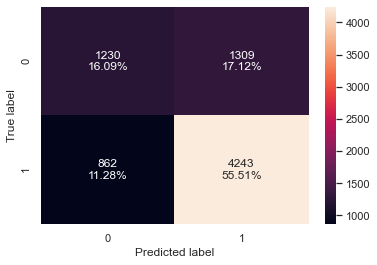

```python
confusion_matrix_sklearn(rf_estimator, X_test, y_test)
```

**There is discrepancy between predictions of training data and test data. We will tune the model with hyperparameter.**

```python
rf_estimator_tuned = RandomForestClassifier(random_state=1)

# creating parameters
parameters = {"n_estimators": [150,200,250],
    "min_samples_leaf": np.arange(5, 10),
    "max_features": [0.7],
    "max_samples": np.arange(0.3, 0.7, 0.1)
             }

# Type of scoring used to compare parameter combinations
acc_scorer = metrics.make_scorer(metrics.recall_score)

# Run the grid search
grid_obj = GridSearchCV(rf_estimator_tuned, parameters, scoring=acc_scorer,cv=5)
grid_obj = grid_obj.fit(X_train, y_train)

# Set the clf to the best combination of parameters
rf_estimator_tuned = grid_obj.best_estimator_

# Fit the best algorithm to the data.
rf_estimator_tuned.fit(X_train, y_train)
```

```
RandomForestClassifier(max_features=0.7, max_samples=0.3, min_samples_leaf=9,
                       n_estimators=150, random_state=1)
```

```python
rf_model_perf_train_tuned= get_score(rf_estimator_tuned, X_train, y_train)
print("Training performance \n", rf_model_perf_train_tuned)
```

```
Training performance
    Accuracy    Recall  Precision        F1
0  0.771529  0.885084   0.795774  0.838056
```

```python
rf_model_perf_test_tuned= get_score(rf_estimator_tuned, X_test, y_test)
print("Training performance \n", rf_model_perf_test_tuned)
```

```
Training performance
    Accuracy    Recall  Precision        F1
0  0.739796  0.867385   0.771429  0.816598
```

### Adaboosting classifier

```python
abc = AdaBoostClassifier(random_state=1) #to train the adaboost classifier
abc.fit(X_train,y_train)
```

```
AdaBoostClassifier(random_state=1)
```

```python
abc_score_train= get_score(abc, X_train, y_train)
print("Training performance \n", abc_score_train)
```

```
Training performance
    Accuracy    Recall  Precision       F1
0  0.734806  0.885587   0.758066  0.81688
```

```python
abc_score_test = get_score(abc, X_test, y_test)
print("Training performance \n", abc_score_test)
```

```
Training performance
    Accuracy    Recall  Precision       F1
0  0.729723  0.884035     0.7538  0.81374
```

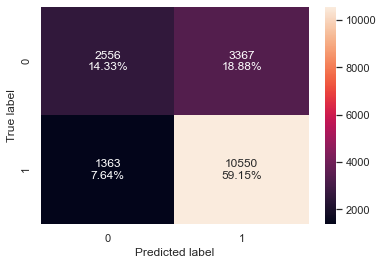

```python
confusion_matrix_sklearn(abc, X_train, y_train)
```

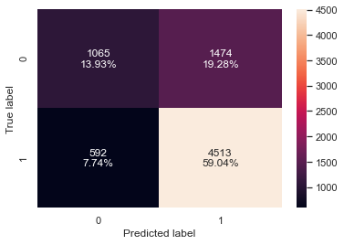

```python
confusion_matrix_sklearn(abc, X_test, y_test)
```

**Although the training and test data have similar scores, we will try to tune the model to see if we can get better model scores. Also, we will try to use fixed parameters where ever possible to reduce the time taken to run tune the model.

```python
abc_tuned = AdaBoostClassifier(random_state=1)

# Grid of parameters to choose from
## add from article
parameters = {
    #Let's try different max_depth for base_estimator
    "base_estimator":[DecisionTreeClassifier(max_depth=1, random_state=1)],
    "n_estimators": np.arange(10,110,10),
    "learning_rate":np.arange(0.1,2,0.1)
}

# Type of scoring used to compare parameter combinations
acc_scorer = metrics.make_scorer(metrics.recall_score)

# Run the grid search
grid_obj = GridSearchCV(abc_tuned, parameters, scoring=acc_scorer,cv=5)
grid_obj = grid_obj.fit(X_train, y_train)

# Set the clf to the best combination of parameters
abc_tuned = grid_obj.best_estimator_

# Fit the best algorithm to the data.
abc_tuned.fit(X_train, y_train)
```

```
AdaBoostClassifier(base_estimator=DecisionTreeClassifier(max_depth=1,
                                                         random_state=1),
                   learning_rate=0.2, n_estimators=10, random_state=1)
```

```python
abc_perf_train_tuned= get_score(abc, X_train, y_train)
print("Training performance \n", abc_perf_train_tuned)
```

```
Training performance
    Accuracy    Recall  Precision       F1
0  0.734806  0.885587   0.758066  0.81688
```

```python
abc_perf_test_tuned = get_score(abc, X_test, y_test)
print("Training performance \n", abc_perf_test_tuned)
```

```
Training performance
    Accuracy    Recall  Precision       F1
0  0.729723  0.884035     0.7538  0.81374
```

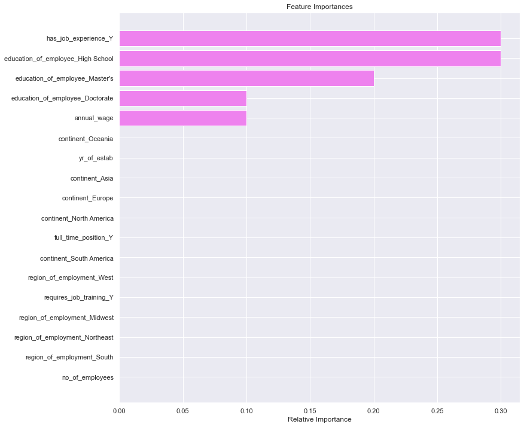

```python
importances = abc_tuned.feature_importances_
indices = np.argsort(importances)
feature_names = list(X.columns)

plt.figure(figsize=(12,12))
plt.title('Feature Importances')
plt.barh(range(len(indices)), importances[indices], color='violet', align='center')
plt.yticks(range(len(indices)), [feature_names[i] for i in indices])
plt.xlabel('Relative Importance')
plt.show()
```

**Feature is showing that among all predictors job experience and education are most important factors in deciding the visa being certifed or denied.**